# Dados de commits no github

```r
library(here)
library(tidyverse)
library(lubridate)
library(timeDate)
library(resample)
theme_set(theme_bw())
```

```r
readr::read_csv(here::here("data/github-users-committing-filetypes.csv"),
                      progress = FALSE,
                      col_types = cols(
                        file_extension = col_character(),
                        month_day = col_integer(),
                        the_month = col_integer(),
                        the_year = col_integer(),
                        users = col_integer()
                        )) -> data
data %>%
  glimpse()
```

```
Observations: 13,802
Variables: 5
$ file_extension <chr> "md", "md", "md", "md", "md", "md", "md", "md", "md", "md", "md", "md", "md", "md", "md", "md", "m...
$ month_day      <int> 18, 17, 27, 16, 26, 21, 4, 22, 23, 1, 12, 3, 2, 21, 26, 22, 19, 25, 1, 6, 11, 2, 19, 28, 24, 19, 1...
$ the_month      <int> 2, 2, 1, 2, 1, 3, 2, 2, 2, 2, 4, 2, 2, 2, 4, 3, 4, 1, 3, 4, 2, 3, 1, 1, 2, 2, 4, 2, 4, 2, 3, 2, 2,...
$ the_year       <int> 2016, 2016, 2016, 2016, 2016, 2017, 2016, 2016, 2016, 2016, 2016, 2016, 2016, 2017, 2016, 2017, 20...
$ users          <int> 10279, 10208, 10118, 10045, 10020, 10015, 9991, 9962, 9959, 9946, 9894, 9876, 9865, 9837, 9785, 97...
```

```r
dados = data  %>% filter(file_extension == "go" | file_extension == "rb")
```

## Para cada uma delas, há uma diferença significativa na sua popularidade durante a semana e durante o fim de semana? Essa diferença é grande?

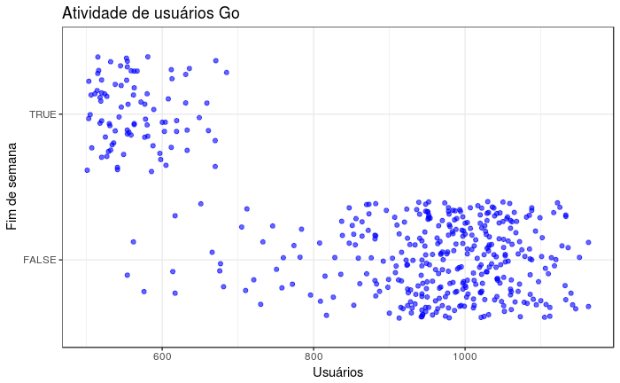

```r
dados %>%
  filter(file_extension == "go" ) %>%
  ggplot(aes(x= users ,y = isWeekend)) + geom_jitter(width = .1, colour = "blue",alpha=0.6)+
  labs(title = "Atividade de usuários Go", x = "Usuários", y = "Fim de semana")
```

Cada ponto é um dia em que houve atividade no GitHub para a linguagem Go. Esse dia pode ter sido no final de semana ou não. Vemos que há uma concentração de dias que não são finais de semana e em que houve um número alto de usuários que programaram em Go. Em contrapartida, há uma concentração de dias que são do final de semana e em que houve um número mais baixo de usuários. Isso nos sugere que Go é mais popular em dias de semana do que em finais de semana.

Em linha gerais, a técnica bootstrap funciona da seguinte maneira:

- Reescreve um conjunto de dados do mesmo tamanho da amostra original n vezes.
- Calcula a estatísca para cada amostra gerada;
- Encontra o desvio padrão desta estatística;

```r
go1 = dados %>%
  filter(file_extension == "go" || isWeekend == TRUE) %>%
  bootstrap(median(users))
md_go_week = go1 %>%
    CI.percentile(probs = c(.025, .975))
```

[output not shown]